# Project 1: Text Mining

Yvonne Zha lz2806

## Can ‘Schools’ in Philosophy represent the similarity between philosophers?

Speaking of great philosophers, you may come up with Plato, Aristotle, etc. However, how will you explain the relationship of these philosophers? Schools can be a good perspective to investigate into this problem. As a non-expert in philosophy, the very first question I would like to propose is: what does that ‘School’ stands for here? Does ‘School’ explain the similarity between philosophers, or it’s just a meaningless property? My hypothesis here would be: ‘School’ can actually explain the similarity between philosophers. To verify my hypothesis, I decide to use Text Mining techiques, especially Topic Modeling, to cluter the philosophers, and finally compare the results with the schools which these philosophers belong to. Furthermore, I would also like to investigate the relationship between schools.

## Part 1: Set Up Environment and Data Processing

```r
packages.used=c("ggplot2", "tibble",
                "dplyr", "textmineR", "wordcloud",
                "topicmodels", "factoextra", "quanteda",
                "tm", "tidyverse", "tidytext")
# check packages that need to be installed.
packages.needed=setdiff(packages.used,
                        intersect(installed.packages()[,1],
                                  packages.used))
# install additional packages
if(length(packages.needed)>0){
  install.packages(packages.needed, dependencies = TRUE)
}

# load packages
library(ggplot2)
library(tibble)
library(dplyr)
library(textmineR)
library(wordcloud)
library(topicmodels)
library(factoextra)
library(quanteda)
library(tm)
library(tidyverse)
library(tidytext)
```

```r
# Read in data
file.path <- "../data/philosophy_data.csv"
file <- read.csv(file.path, encoding = "UTF-8")
head(file)
```

|  | title | author | school | sentence_spacy | sentence_str | original_publication_date | corpus_edition_date | sentence_length | sentence_lowered | tokenized_txt | lemmatized_str |
| --- | --- | --- | --- | --- | --- | --- | --- | --- | --- | --- | --- |
| 1 | Plato - Complete Works | Plato | plato | What's new, Socrates, to make you leave your usual haunts in the Lyceum and spend your time here by the king archon's court? | What's new, Socrates, to make you leave your usual haunts in the Lyceum and spend your time here by the king archon's court? | -350 | 1997 | 125 | what's new, socrates, to make you leave your usual haunts in the lyceum and spend your time here by the king archon's court? | ['what', 'new', 'socrates', 'to', 'make', 'you', 'leave', 'your', 'usual', 'haunts', 'in', 'the', 'lyceum', 'and', 'spend', 'your', 'time', 'here', 'by', 'the', 'king', 'archon', 'court'] | what be new , Socrates , to make -PRON- leave -PRON- usual haunt in the Lyceum and spend -PRON- time here by the king archon 's court ? |
| 2 | Plato - Complete Works | Plato | plato | Surely you are not prosecuting anyone before the king archon as I am? | Surely you are not prosecuting anyone before the king archon as I am? | -350 | 1997 | 69 | surely you are not prosecuting anyone before the king archon as i am? | ['surely', 'you', 'are', 'not', 'prosecuting', 'anyone', 'before', 'the', 'king', 'archon', 'as', 'am'] | surely -PRON- be not prosecute anyone before the king archon as -PRON- be ? |
| 3 | Plato - Complete Works | Plato | plato | The Athenians do not call this a prosecution but an indictment, Euthyphro. | The Athenians do not call this a prosecution but an indictment, Euthyphro. | -350 | 1997 | 74 | the athenians do not call this a prosecution but an indictment, euthyphro. | ['the', 'athenians', 'do', 'not', 'call', 'this', 'prosecution', 'but', 'an', 'indictment', 'euthyphro'] | the Athenians do not call this a prosecution but an indictment , Euthyphro . |
| 4 | Plato - Complete Works | Plato | plato | What is this you say? | What is this you say? | -350 | 1997 | 21 | what is this you say? | ['what', 'is', 'this', 'you', 'say'] | what be this -PRON- say ? |
| 5 | Plato - Complete Works | Plato | plato | Someone must have indicted you, for you are not going to tell me that you have indicted someone else. | Someone must have indicted you, for you are not going to tell me that you have indicted someone else. | -350 | 1997 | 101 | someone must have indicted you, for you are not going to tell me that you have indicted someone else. | ['someone', 'must', 'have', 'indicted', 'you', 'for', 'you', 'are', 'not', 'going', 'to', 'tell', 'me', 'that', 'you', 'have', 'indicted', 'someone', 'else'] | someone must have indict -PRON- , for -PRON- be not go to tell -PRON- that -PRON- have indict someone else . |
| 6 | Plato - Complete Works | Plato | plato | But someone else has indicted you? | But someone else has indicted you? | -350 | 1997 | 34 | but someone else has indicted you? | ['but', 'someone', 'else', 'has', 'indicted', 'you'] | but someone else have indict -PRON- ? |

```r
summary(file)
```

```
    title              author             school          sentence_spacy     sentence_str
 Length:360808      Length:360808      Length:360808      Length:360808      Length:360808
 Class :character   Class :character   Class :character   Class :character   Class :character
 Mode  :character   Mode  :character   Mode  :character   Mode  :character   Mode  :character



 original_publication_date corpus_edition_date sentence_length  sentence_lowered   tokenized_txt
 Min.   :-350              Min.   :1887        Min.   :  20.0   Length:360808      Length:360808
 1st Qu.:1641              1st Qu.:1991        1st Qu.:  75.0   Class :character   Class :character
 Median :1817              Median :2001        Median : 127.0   Mode  :character   Mode  :character
 Mean   :1327              Mean   :1995        Mean   : 150.8
 3rd Qu.:1949              3rd Qu.:2007        3rd Qu.: 199.0
 Max.   :1985              Max.   :2016        Max.   :2649.0
 lemmatized_str
 Length:360808
 Class :character
 Mode  :character
```

## Part 2: Exploratory Data Analysis

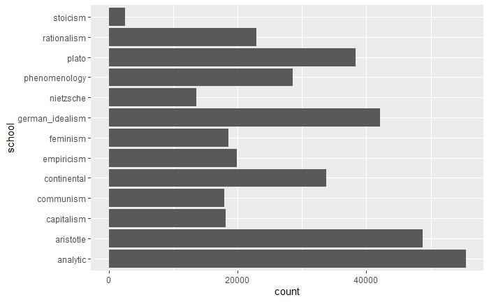

```r
ggplot(file) +
  geom_bar(aes(y = school))
```

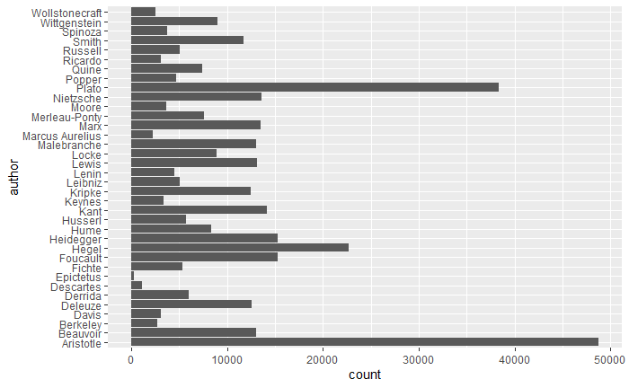

```r
ggplot(file) +
  geom_bar(aes(y = author))
```

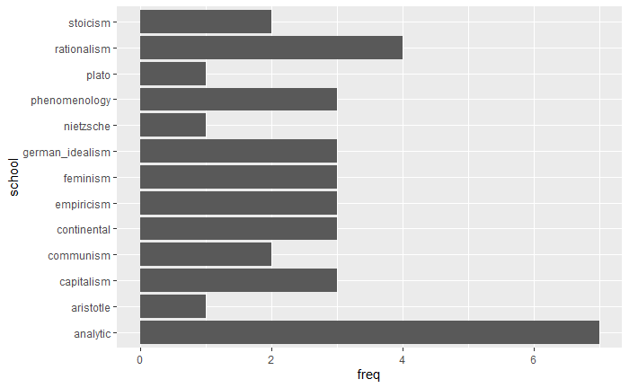

```r
count_df <- unique(file[c("author", "school")])
tab <- table(count_df$school)
df <- data.frame(school = names(tab), freq = as.numeric(tab))
ggplot(df) +
  geom_bar(stat = "identity", aes(x=freq, y=school))
```

In this dataset, Analytic and Aristotle have the highest number of sentences among all the schools, while individually Aristotle and Plato are the most productive philosophers. For each school, Analytic has most philosophers, while Aristotle, Plato, Nietzsche are individual philosophers who did not belong to any school.

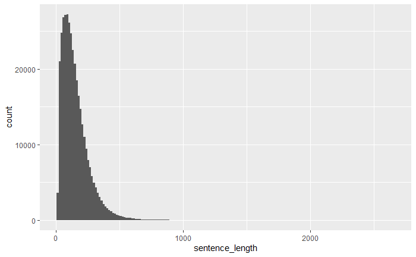

```r
ggplot(file) +
  geom_histogram(aes(x = sentence_length), binwidth = 15)
```

The length of each sentence is possibly the log-normal distribution. It’s heavily right-skewed, indicating that there is a small amount of outliers, which are long and complicated sentences.

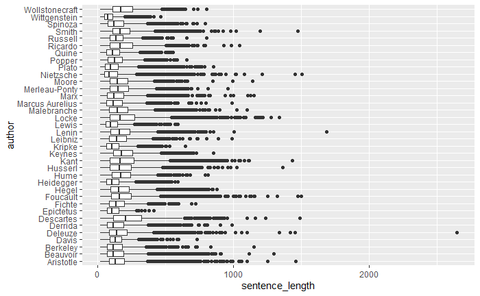

```r
ggplot(file) +
  geom_boxplot(aes(x = sentence_length, y = author))
```

Looking at the largest median and smallest median, we can find that Wittgenstein has shortest sentence on avgerage, while Descartes has longest on average. Let’s take a look at their most shortest and longest sentences.

```r
# Look into Wittgenstein
file %>%
  filter(author == "Wittgenstein",
         sentence_length <= 50) %>%
  select(sentence_spacy) %>%
  sample_n(10)
```

| sentence_spacy |
| --- |
| What consequences has this information? |
| I am not of the opinion that he has a soul. |
| He seems to believe. . . |
| what if I did make a mistake then, after all? |
| What kind of actions accompany these words? |
| Here is a Chinese sentence or |
| We might also say: Every thing fits into itself. |
| Here it strikes me as if this doubt were hollow. |
| This rod is one yard long |
| I feel as if these words were like |

```r
# Look into Descartes
file %>%
  filter(author == "Descartes",
         sentence_length >= 1000) %>%
  select(sentence_spacy) %>%
  sample_n(1)
```

| sentence_spacy |
| --- |
| And, in the last place, what above all is here worthy of observation, is the generation of the animal spirits, which are like a very subtle wind, or rather a very pure and vivid flame which, continual… |

The short senetences are more striking and clear, while long sentences are more complicated to understand. From this perspective maybe we can say Wittgenstein is more understandable for readers than Descartes.

## Part 3: How is each philosopher differ from each other – Topic modeling and Clustering for philosophers

```r
dtm <- CreateDtm(file$sentence_lowered,
                 doc_names = file$author
                 )
doc_lengths <- Matrix::rowSums(dtm)
dtm1 <- dtm[doc_lengths > 0, ]
file1 <- file[doc_lengths > 0, ]
```

Build LDA model.

```r
# LDA modeling
# k=5: classify into five topics
k <- 5
ldaOut <- LDA(dtm1, k, control = list(seed = 1234))

# results
ldaOut.topics <- as.matrix(topics(ldaOut))
table(c(1:k, ldaOut.topics))
```

```
    1     2     3     4     5
72293 73630 70611 71913 69456
```

```r
ldaOut.terms
```

```
      Topic 1      Topic 2         Topic 3    Topic 4    Topic 5
 [1,] "case"       "world"         "time"     "time"     "things"
 [2,] "nature"     "thing"         "man"      "nature"   "man"
 [3,] "man"        "sense"         "life"     "man"      "world"
 [4,] "part"       "god"           "sense"    "things"   "part"
 [5,] "power"      "existence"     "great"    "reason"   "reason"
 [6,] "make"       "knowledge"     "god"      "make"     "body"
 [7,] "experience" "people"        "object"   "relation" "good"
 [8,] "order"      "mind"          "true"     "thing"    "nature"
 [9,] "body"       "natural"       "pure"     "place"    "great"
[10,] "thing"      "general"       "form"     "case"     "time"
[11,] "people"     "kind"          "truth"    "idea"     "hand"
[12,] "things"     "state"         "relation" "form"     "fact"
[13,] "ideas"      "matter"        "things"   "truth"    "natural"
[14,] "language"   "consciousness" "parts"    "good"     "life"
[15,] "human"      "object"        "call"     "true"     "means"
[16,] "time"       "good"          "point"    "fact"     "general"
[17,] "thought"    "reason"        "general"  "present"  "existence"
[18,] "true"       "men"           "work"     "object"   "human"
[19,] "mind"       "greater"       "objects"  "state"    "kind"
[20,] "content"    "things"        "movement" "called"   "subject"
```

Cluster each philosopher based on the results of LDA.

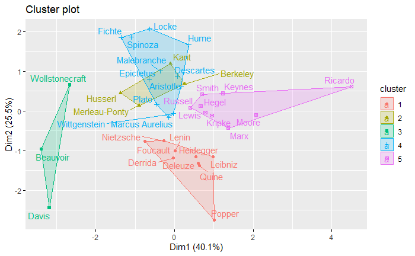

```r
topicProbabilities <- as.data.frame(ldaOut@gamma)
file1$ldatopic <- as.vector(ldaOut.topics)
file1 <- cbind(file1, topicProbabilities)
presid.summary <- tbl_df(file1)%>%
  select(author, V1:V5)%>%
  group_by(author)%>%
  summarise_each(funs(mean))
presid.summary <- as.data.frame(presid.summary)
rownames(presid.summary) <- as.character((presid.summary[,1]))
km.res <- kmeans(scale(presid.summary[,-1]), iter.max=1000,
              5)
options(ggrepel.max.overlaps = Inf)
fviz_cluster(km.res,
             stand=T, repel= TRUE,
             data = presid.summary[,-1],
             show.clust.cent=FALSE)
```

```r
unique(file1[c("author", "school")])
```

|  | author | school |
| --- | --- | --- |
| 1 | Plato | plato |
| 38367 | Aristotle | aristotle |
| 87146 | Locke | empiricism |
| 96031 | Hume | empiricism |
| 104343 | Berkeley | empiricism |
| 107077 | Spinoza | rationalism |
| 110870 | Leibniz | rationalism |
| 115897 | Descartes | rationalism |
| 117029 | Malebranche | rationalism |
| 130026 | Russell | analytic |

[output cut: 26 more lines]

## Part 4: How is each school differ from each other – Topic modeling and Clustering for schools

Run LDA.

```r
# Topic modeling for schools
# genearate TermDocumentMatrix
dtm_s <- CreateDtm(file$sentence_lowered,
                 doc_names = file$school
                 )
doc_lengths <- Matrix::rowSums(dtm_s)
dtm2 <- dtm_s[doc_lengths > 0, ]
file2 <- file[doc_lengths > 0, ]
```

```r
# LDA modeling
# k=5: classify into five topics
k <- 5
ldaOut2 <- LDA(dtm2, k, control = list(seed = 1234))

# results
ldaOut.topics2 <- as.matrix(topics(ldaOut2))
table(c(1:k, ldaOut.topics2))
```

```
    1     2     3     4     5
72293 73630 70611 71913 69456
```

```r
ldaOut.terms2
```

```
      Topic 1      Topic 2         Topic 3    Topic 4    Topic 5
 [1,] "case"       "world"         "time"     "time"     "things"
 [2,] "nature"     "thing"         "man"      "nature"   "man"
 [3,] "man"        "sense"         "life"     "man"      "world"
 [4,] "part"       "god"           "sense"    "things"   "part"
 [5,] "power"      "existence"     "great"    "reason"   "reason"
 [6,] "make"       "knowledge"     "god"      "make"     "body"
 [7,] "experience" "people"        "object"   "relation" "good"
 [8,] "order"      "mind"          "true"     "thing"    "nature"
 [9,] "body"       "natural"       "pure"     "place"    "great"
[10,] "thing"      "general"       "form"     "case"     "time"
[11,] "people"     "kind"          "truth"    "idea"     "hand"
[12,] "things"     "state"         "relation" "form"     "fact"
[13,] "ideas"      "matter"        "things"   "truth"    "natural"
[14,] "language"   "consciousness" "parts"    "good"     "life"
[15,] "human"      "object"        "call"     "true"     "means"
[16,] "time"       "good"          "point"    "fact"     "general"
[17,] "thought"    "reason"        "general"  "present"  "existence"
[18,] "true"       "men"           "work"     "object"   "human"
[19,] "mind"       "greater"       "objects"  "state"    "kind"
[20,] "content"    "things"        "movement" "called"   "subject"
```

Cluster each school based on the results of LDA.

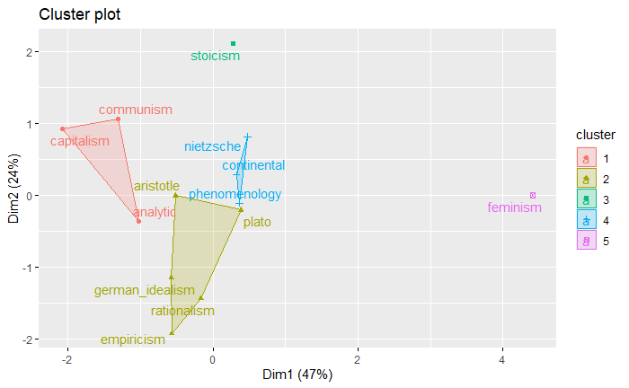

```r
topicProbabilities2 <- as.data.frame(ldaOut2@gamma)
file2$ldatopic <- as.vector(ldaOut.topics2)
file2 <- cbind(file2, topicProbabilities2)
presid.summary2 <- tbl_df(file2)%>%
  select(school, V1:V5)%>%
  group_by(school)%>%
  summarise_each(funs(mean))
presid.summary2 <- as.data.frame(presid.summary2)
rownames(presid.summary2) <- as.character((presid.summary2[,1]))
km.res2 <- kmeans(scale(presid.summary2[,-1]), iter.max=1000,
              5)
options(ggrepel.max.overlaps = Inf)
fviz_cluster(km.res2,
             stand=T, repel= TRUE,
             data = presid.summary2[,-1],
             show.clust.cent=FALSE)
```

We conclude that Captilalism, Communism, Analystic are close, German idealism, Empiricism and Rationalism are close, while feminism are different from other schools. We are excited to say this coincides with the conclusions in Part 3 to some extent!

## Part 5: Case Analysis – Feminism

Let’s take a look at a specific case! The special school we would like to investigate is feminism. We could use a wordcloud to have an idea of what this school is about.

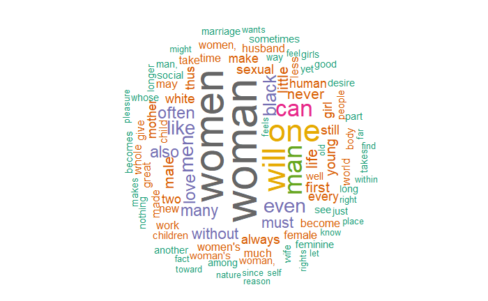

Feminism, as we know, mainly focus on women. But men can still be a important word in the arguments of feminism. Words equivalent to women are also appearing a lot, such as female or girl.